# SWC Lincoln University - Programming with R

**Important notice:** This course material is mostly based on the Software Carpentry lessons “Programming with R”, version 5.3 (http://software-carpentry.org/lessons.html).

# Lesson 1: Analysing Patient Data

We are studying inflammation in patients who have been given a new treatment for arthritis, and need to analyze the first dozen data sets. The data is stored in comma-separated values (CSV) format. It can be easily inspected with a text editor or spreadsheet program, such as LibreOffice Calc or Microsoft Excel. Each row holds the observations for just one patient. Each column holds the inflammation measured in a day, so we have a set of values in successive days. The first few rows of our first file look like this:

```
0,0,1,3,1,2,4,7,8,3,3,3,10,5,7,4,7,7,12,18,6,13,11,11,7,7,4,6,8,8,4,4,5,7,3,4,2,3,0,0
0,1,2,1,2,1,3,2,2,6,10,11,5,9,4,4,7,16,8,6,18,4,12,5,12,7,11,5,11,3,3,5,4,4,5,5,1,1,0,1
0,1,1,3,3,2,6,2,5,9,5,7,4,5,4,15,5,11,9,10,19,14,12,17,7,12,11,7,4,2,10,5,4,2,2,3,2,2,1,1
0,0,2,0,4,2,2,1,6,7,10,7,9,13,8,8,15,10,10,7,17,4,4,7,6,15,6,4,9,11,3,5,6,3,3,4,2,3,2,1
0,1,1,3,3,1,3,5,2,4,4,7,6,5,3,10,8,10,6,17,9,14,9,7,13,9,12,6,7,7,9,6,3,2,2,4,2,0,1,1
```

We want to:

- Load data into memory,
- Calculate the average value of inflammation per day across all patients, and
- Plot the results.

To do all that, we’ll have to learn a little bit about programming.

## Loading Data

To load our inflammation data, first we need to tell our computer where is the file that contains the values. We have been told its name is `inflammation-01.csv`. This is very important in R, if we forget this step we’ll get an error message when trying to read the file. We can change the current working directory using the function `setwd`. For this example, we change the path to the working directory where our scripts are stored:

```r
setwd("~/swc_lincoln2015/R_Lessons")
```

**Note for Windows users:** R was originally developed for Unix-type platforms, where forward slashes `/` are used for file paths as in the example above. Windows inherited backslashes `\` from MS-DOS. Backslashes have a different meaning in R, but they may still be used if doubled up (`\\`). However, it is advisable to use forward slashes `/`, so that users with Unix-type operating systems can run your programs on their computers. Moreover, using the tilde `~` in R means the “Documents” directory for the current user in Windows, whereas it means the home directory in a Unix-type operating system.

Alternatively you can change the working directory using the RStudio GUI using the menu option `Session` -> `Set Working Directory` -> `Choose Directory...`.

We can load the data into R using the `read.csv` function:

```
read.csv(file = "data/inflammation-01.csv", header = FALSE)
```

`read.csv` has two arguments: the name of the file we want to read, and whether the first line of the file contains names for the columns of data. The filename needs to be a character string (or string for short), so we put it in quotes. Assigning the second argument, `header`, to be `FALSE` indicates that the data file does not have column headers.

Since we didn’t tell it to do anything else with the function’s output, the console will display the full contents of the file `inflammation-01.csv`, and we can’t use data unless we assign it to a variable.

A variable is just a name for a value, such as `x`, `current_temperature`, or `subject_id`. We can create a new variable simply by assigning a value to it using the assignment operator `<-`

```r
weight_kg <- 55
```

In general, R will print to the console any object returned by a function or operation *unless* we assign it to a variable.

```r
weight_kg
```

```
## [1] 55
```

We can also use the `print` function for parantheses `()` for printing variable values:

```r
print(weight_kg)
```

```
## [1] 55
```

```r
(weight_kg)
```

```
## [1] 55
```

We can do arithmetic with the variable:

```r
# weight in pounds:
2.2 * weight_kg
```

```
## [1] 121
```

**Note** The `#` character is used for comments in the code, which is useful to document things so that others (and us the next time we read it) have an easier time following what the code is doing.

We can change the variable’s value:

```r
weight_kg <- 57.5
# weight in kilograms is now
weight_kg
```

```
## [1] 57.5
```

## Hands-on: Variables

Draw diagrams showing which variables refer to which values after each statement in the following program:

```
# Weight and age on Earth
location <- "Earth"
weight <- 50
age <- 35
# Take a trip to Pluto with "New Horizons" space probe
location <- "Pluto"
weight <- weight * 0.063
age <- age + 9
```

What does the following program print out (don’t use the computer!)?

```
my_favourite_colour <- "blue"
your_favourite_colour <- "red"
your_favourite_colour <- my_favourite_colour
print("Your favourite colour is:")
print(your_favourite_colour)
```

1. “my_favourite_colour”
2. “red”
3. “your_favourite_colour”
4. “blue”

## Manipulating data

Now that we know how to assign things to variables, let’s re-run `read.csv` and save its result:

```r
dat <- read.csv(file = "data/inflammation-01.csv", header = FALSE)
```

Let’s look at the first and last lines:

```
head(dat)
tail(dat)
```

Now that our data is loaded in memory, we can start doing things with it. First, let’s ask what type of thing `dat` is:

```r
class(dat)
```

```
## [1] "data.frame"
```

Data frames are very similar to spreadsheets, they are very useful for storing and handling tabulated data. We can see the dimensions, or shape, of the data frame with the function `dim`:

```r
dim(dat)
```

```
## [1] 60 40
```

The data frame has 60 rows and 40 columns.

We can access single values from the data frame using indices:

```r
# first value in dat
dat[1, 1]
```

```
## [1] 0
```

```r
# middle value in dat
dat[30, 20]
```

```
## [1] 16
```

An index like `[30, 20]` selects a single element of a data frame, but we can select whole sections as well. For example, we can select the first ten days (columns) of values for the first four patients (rows) like this:

```r
dat[1:4, 1:10]
```

```
##   V1 V2 V3 V4 V5 V6 V7 V8 V9 V10
## 1  0  0  1  3  1  2  4  7  8   3
## 2  0  1  2  1  2  1  3  2  2   6
## 3  0  1  1  3  3  2  6  2  5   9
## 4  0  0  2  0  4  2  2  1  6   7
```

The slice `1:4` means, “Start at index 1 and go to index 4.”

The slice does not need to start at 1, e.g. the line below selects rows 5 through 10:

```r
dat[5:10, 1:10]
```

```
##    V1 V2 V3 V4 V5 V6 V7 V8 V9 V10
## 5   0  1  1  3  3  1  3  5  2   4
## 6   0  0  1  2  2  4  2  1  6   4
## 7   0  0  2  2  4  2  2  5  5   8
## 8   0  0  1  2  3  1  2  3  5   3
## 9   0  0  0  3  1  5  6  5  5   8
## 10  0  1  1  2  1  3  5  3  5   8
```

We can use the function `c`, which stands for combine, to select non-contiguous values:

```r
dat[c(3, 8, 37, 56), c(10, 14, 29)]
```

```
##    V10 V14 V29
## 3    9   5   4
## 8    3   5   6
## 37   6   9  10
## 56   7  11   9
```

If row indices or column indices are omitted, R returns all rows or columns, respectively:

```r
# All columns from row 5
dat[5, ]
```

```
##   V1 V2 V3 V4 V5 V6 V7 V8 V9 V10 V11 V12 V13 V14 V15 V16 V17 V18 V19 V20
## 5  0  1  1  3  3  1  3  5  2   4   4   7   6   5   3  10   8  10   6  17
##   V21 V22 V23 V24 V25 V26 V27 V28 V29 V30 V31 V32 V33 V34 V35 V36 V37 V38
## 5   9  14   9   7  13   9  12   6   7   7   9   6   3   2   2   4   2   0
##   V39 V40
## 5   1   1
```

```r
# All rows from column 16
dat[, 16]
```

```
##  [1]  4  4 15  8 10 15 13  9 11  6  3  8 12  3  5 10 11  4 11 13 15  5 14
## [24] 13  4  9 13  6  7  6 14  3 15  4 15 11  7 10 15  6  5  6 15 11 15  6
## [47] 11 15 14  4 10 15 11  6 13  8  4 13 12  9
```

## Hands-on: Indexing

More indexing tricks: what do the following lines return (try it on your computer)?

```
dat[-3,]
dat[, -7:-11]
dat[1, -1]
```

A vector is a variable that has any number of elements of the same type, such as integer numbers, character strings, etc. A list is a variable that has any number of elements of mixed (or same) type. We can take slices of vectors and lists as well:

```r
# Vector: elements must have same type
animal <- c("m", "o", "n", "k", "e", "y")
# first three characters
animal[1:3]
```

```
## [1] "m" "o" "n"
```

```r
# last three characters
animal[4:6]
```

```
## [1] "k" "e" "y"
```

```r
# List: elements can have different type
noble_gases <- list("Helium", "He", 2, "Neon", "Ne", 10, "Argon", "Ar", 18)
```

What is the output of the following code?

```
animal[1:4]
animal[-4]
animal[-1:-4]
```

And how can we get the following output from `noble_gases`?

```
noble_gases[?]
"He" "Ne" "Ar"
```

When analyzing data we often want to look at partial statistics, such as the maximum value per patient or the average value per day. One way to do this is to select the data we want to create a new temporary data frame, and then perform the calculation on this subset:

```r
# first row, all of the columns
patient_1 <- dat[1, ]
# max inflammation for patient 1
max(patient_1)
```

```
## [1] 18
```

The selection and function call can also be combined:

```r
# max inflammation for patient 2
max(dat[2, ])
```

```
## [1] 18
```

R has more functions for basic statistics, now used on column 7:

```r
min(dat[, 7])
```

```
## [1] 1
```

```r
mean(dat[, 7])
```

```
## [1] 3.8
```

```r
median(dat[, 7])
```

```
## [1] 4
```

```r
sd(dat[, 7]) # sd = standard deviation
```

```
## [1] 1.725187
```

What if we need the maximum inflammation for all patients, or the average for each day? As the diagram below shows, we want to perform the operation across a margin of the data frame:

[figure not shown]

To support this, we can use the apply function.

**Tip:** To learn about a function in R, e.g. `apply`, we can read its help documention by running `help(apply)` or `?apply`.

`apply` allows us to repeat a function on all of the rows (`MARGIN = 1`) or columns (`MARGIN = 2`) of a data frame. Thus, to obtain the average inflammation of each patient we will need to calculate the mean of all of the rows (`MARGIN = 1`) of the data frame.

```r
avg_patient_inflammation <- apply(dat, 1, mean)
class(avg_patient_inflammation)
```

```
## [1] "numeric"
```

Note how the variable class changed from “data.frame” to “numeric” - the result of the `apply` function is a vector of numbers.

And to obtain the average inflammation of each day we will need to calculate the mean of all of the columns (`MARGIN = 2`) of the data frame.

```r
avg_day_inflammation <- apply(dat, 2, mean)
```

**Tip:** Some common operations have more efficient alternatives. For example, you can calculate the row-wise or column-wise means with `rowMeans` and `colMeans`, respectively.

## Hands-on: Subsetting and basic statistics

Which of the following lines of R code gives the correct answer to the question?

```
# Using slicing and partial statistics, how can we determine the maximum inflamation for patient 5 across days three to seven?
# max(dat[?])
```

1. max(dat[5, ])
2. max(dat[3:7, 5])
3. max(dat[5, 3:7])
4. max(dat[5, 3, 7])

## Plotting

R makes visualising data through plots very easy. To plot average inflammation per day, use:

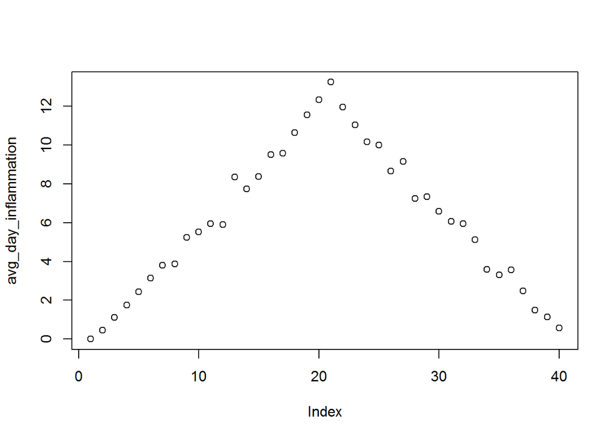

```r
plot(avg_day_inflammation)
```

Above, we gave the function `plot` a vector of numbers corresponding to the average inflammation per day across all patients. `plot` created a scatter plot where the y-axis is the average inflammation level and the x-axis is the order, or index, of the values in the vector, which in this case correspond to the 40 days of treatment.

There are many different types of plots available in R, and the output of functions like `plot` can also change with the variable type used for holding data. One commonly used form to plot data is the “bar plot”:

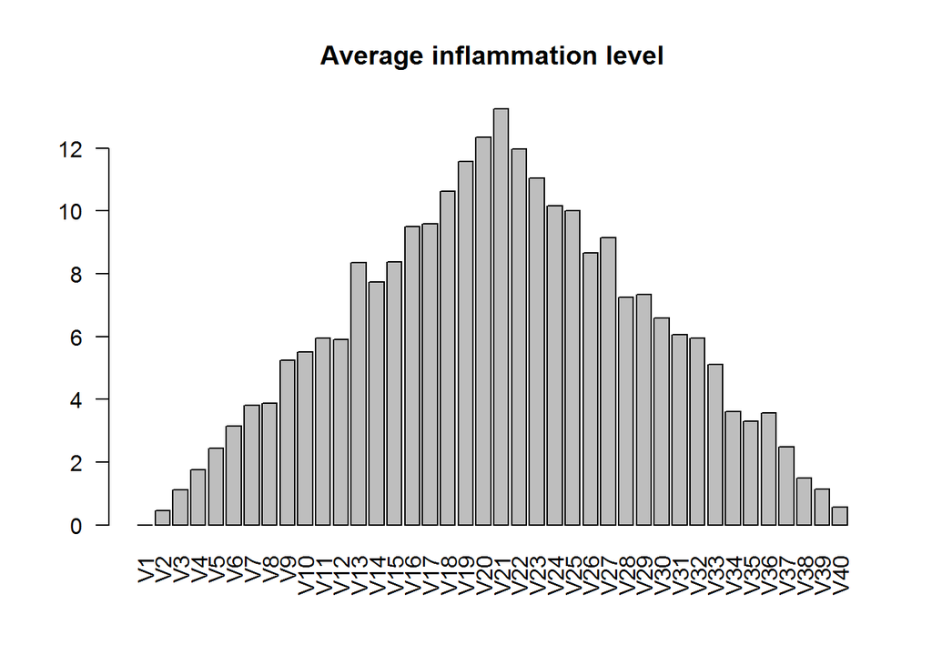

```r
barplot(avg_day_inflammation, las = 2, main = "Average inflammation level")
```

The argument `las` controls the orientation of the labels, `las = 2` means “draw all labels perpendicular to their axis”. The argument `main` sets a plot title.

## Hands-on: Plotting

Create a plot showing the standard deviation of the inflammation data for each day across all patients.

Solution:

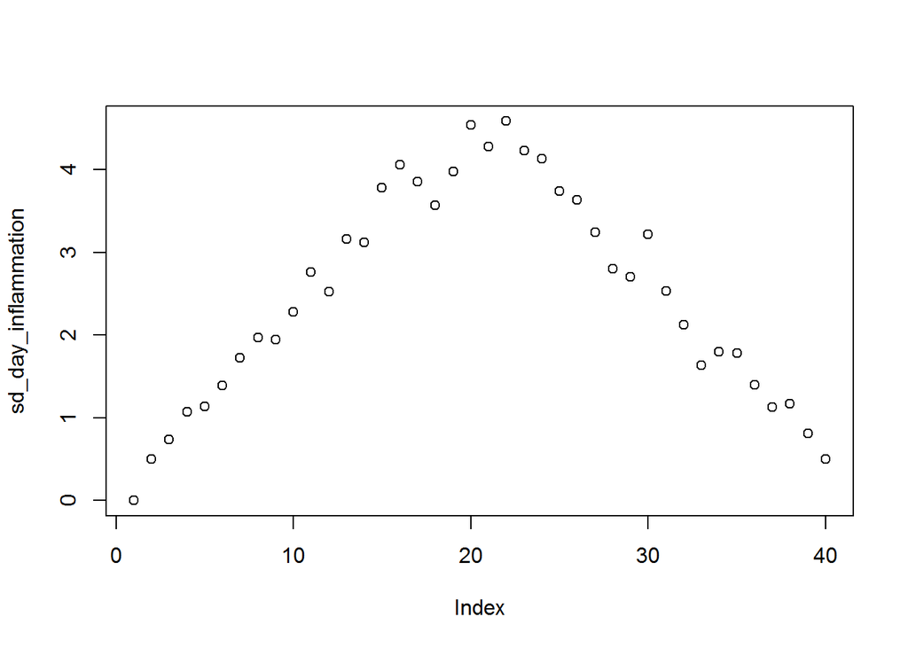

```r
sd_day_inflammation <- apply(dat, 2, sd)
plot(sd_day_inflammation)
```

# Lesson 2: Analysing Multiple Data Sets

We have several data sets to process and analyse. To get a vector with available file names, we can use the `list.files` function:

```
list.files(path = "data", pattern = "csv")
```

The argument `path` tells `list.files` where to look for files, the argument `pattern` can be used to select files whose names match a given pattern.

Of course, we can repeat the same analysis over and over - but it will be frustrating to do so. If you want to become a good programmer, you have to become lazy.

## For Loops

Try printing each character of the vector:

```r
s <- c("W", "e", "l", "l", "i", "n", "g", "t", "o", "n")
s[1]
```

```
## [1] "W"
```

```r
s[2]
```

```
## [1] "e"
```

```r
s[3]
```

```
## [1] "l"
```

```r
s[4]
```

```
## [1] "l"
```

```r
s[5]
```

```
## [1] "i"
```

```r
s[6]
```

```
## [1] "n"
```

```r
s[7]
```

```
## [1] "g"
```

```r
s[8]
```

```
## [1] "t"
```

```r
s[9]
```

```
## [1] "o"
```

```r
s[10]
```

```
## [1] "n"
```

Looping over code manually also invites errors:

```r
s[11]
```

```
## [1] NA
```

The result `NA` (for **N**ot **A**vailable) has special importance in R, as it designates missing data in a statistical sense.

Here is a better approach:

```
for (letter in s)
{
  print(letter)
}
```

This version uses a for loop to repeat an operation. The keyword `in` is part of the `for` syntax, and the body of the loop is enclosed in curly braces `{}`.

Here is another loop that repeatedly updates a variable:

```
len <- 0
for (letter in s)
{
  len <- len + 1
}
# Number of characters
len
```

The number `len` is updated every time the loop is executed, and it keeps its value after the loop has finished.

Note also that finding the length of a vector is such a common operation that R actually has a built-in function to do it called `length`:

```r
length(s)
```

```
## [1] 10
```

## Hands-on: Loops

What does the following code print out - remember, `c` is the combine function (don’t use your computer!)?

```
s1 <- c("N", "e", "w", "t", "o", "n")
s2 <- NULL
for ( char in s1 )
{
  s2 <- c(char, s2)
}
s2
```

1. NULL
2. notweN
3. N, e, w, t, o, n
4. Newton

For experts: In the “wheat and chessboard problem”, we place one grain of wheat on the first square of a chessboard, two grains of wheat on the second square, four grains on the third square, and so on, doubling the number on each subsequent square. A chessboard has 64 squares, and we want to know how many grains we need in total. To solve this problem, write a loop with the following ingredients:

```
# Sq 1: 1 grain, sq 2: 2 grains, sq 3: 4 grains, sq 4: 8 grains
# To generate a sequence of integer numbers from 1 to 64:
seq(1, 64)
# To compute the number of grains for a given square, e.g., square 4:
square_number <- 4
grain_number <- 2^(square_number - 1)
# Sum up all grain numbers and compare the result to the mathematical solution
total_grain_number <- 2^64-1
```

**Note:** There are many different ways to do this, but please use a loop…

Solution:

```
# Reset counter for total number of grains
total_grain_number <- 0
# Loop over integer sequence 1..64
for ( square_number in seq(1, 64) )
{
  # Compute number of grains for this square and add up
  grain_number <- 2^(square_number - 1)
  total_grain_number <- total_grain_number + grain_number
}
# Compare our result with the mathematical solution
total_grain_number
2^64 - 1 # Note: the term -1 will not change the result due to limited numerical precision
```

## Processing Multiple Files

Use the `list.files` function to list all `csv` files or `inflammation` data files in the `data` directory:

```r
list.files(path = "data", pattern = "csv", full.names = TRUE)
```

```
##  [1] "data/inflammation-01.csv" "data/inflammation-02.csv"
##  [3] "data/inflammation-03.csv" "data/inflammation-04.csv"
##  [5] "data/inflammation-05.csv" "data/inflammation-06.csv"
##  [7] "data/inflammation-07.csv" "data/inflammation-08.csv"
##  [9] "data/inflammation-09.csv" "data/inflammation-10.csv"
## [11] "data/inflammation-11.csv" "data/inflammation-12.csv"
```

```r
list.files(path = "data", pattern = "inflammation", full.names = TRUE)
```

```
##  [1] "data/inflammation-01.csv" "data/inflammation-02.csv"
##  [3] "data/inflammation-03.csv" "data/inflammation-04.csv"
##  [5] "data/inflammation-05.csv" "data/inflammation-06.csv"
##  [7] "data/inflammation-07.csv" "data/inflammation-08.csv"
##  [9] "data/inflammation-09.csv" "data/inflammation-10.csv"
## [11] "data/inflammation-11.csv" "data/inflammation-12.csv"
```

**Note:** The parameter `full.names = TRUE` needs to be set so that the file names contain the name of the subdirectory, too.

## Hands-on: Drawing multiple graphs

Write a `for` loop that cycles through the output of the `list.files` function, reads each file with inflammation data using the `read.csv` function and produces plots for inflammation averages per day.

**Tip:** You can set the limits of the y axis to make plots easily comparable. You’ll need to provide both a lower and an upper limit with a vector: `ylim = c(0.0, 14)`.

Solution:

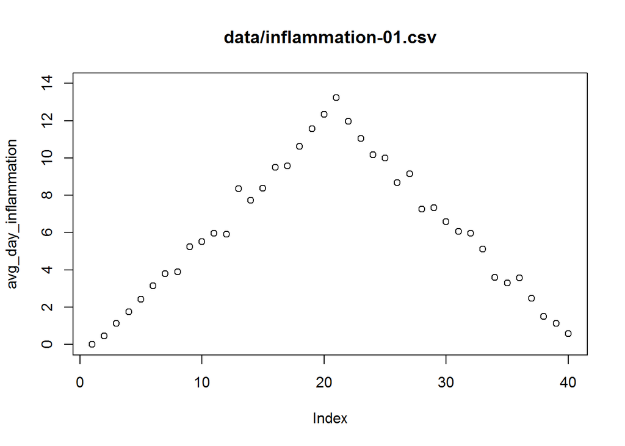

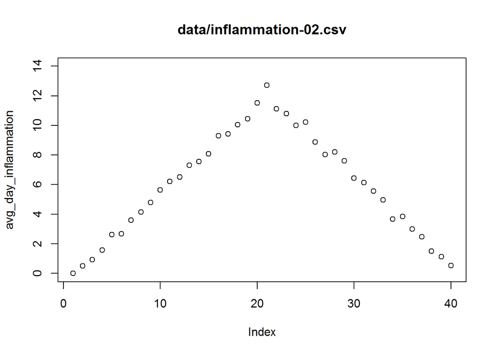

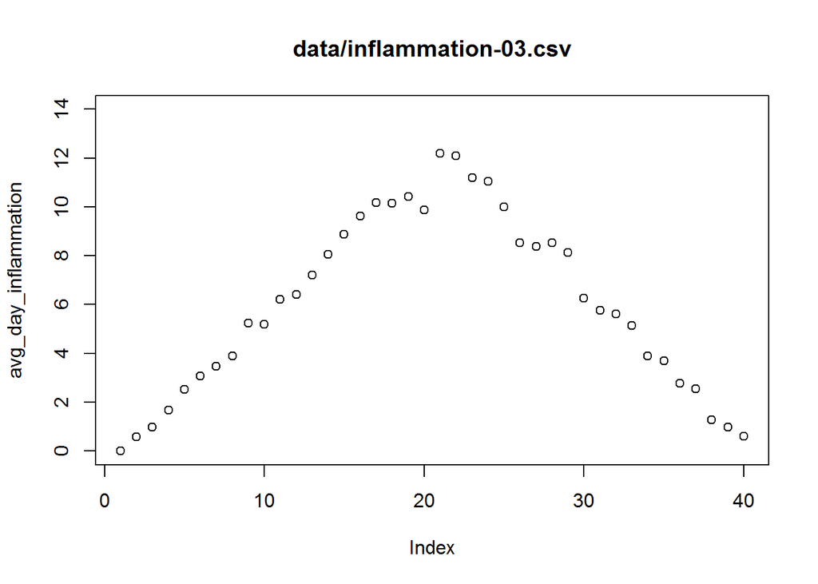

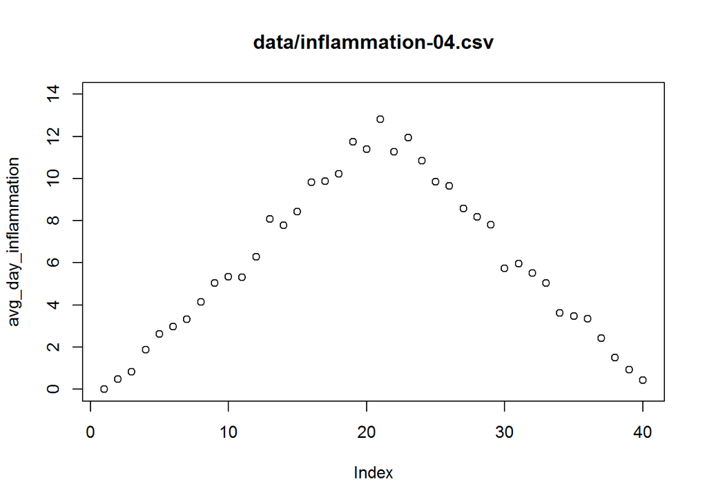

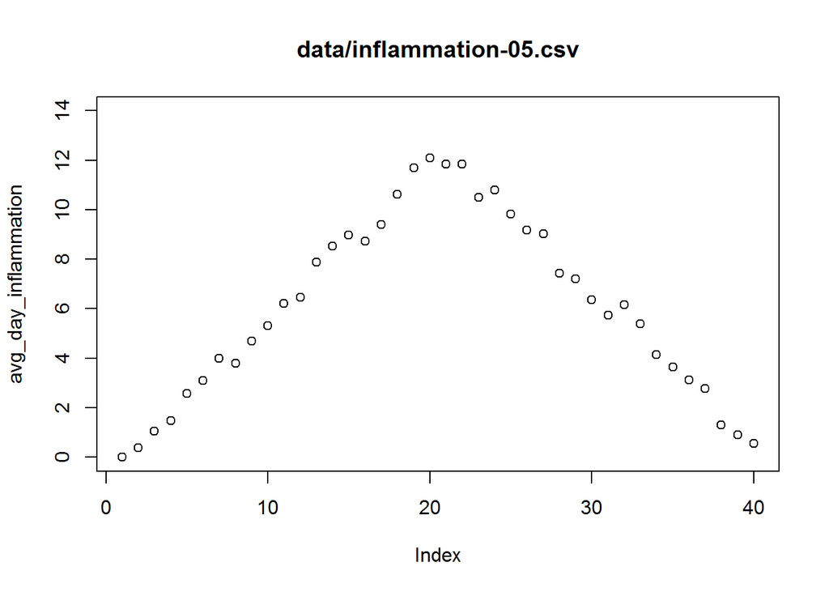

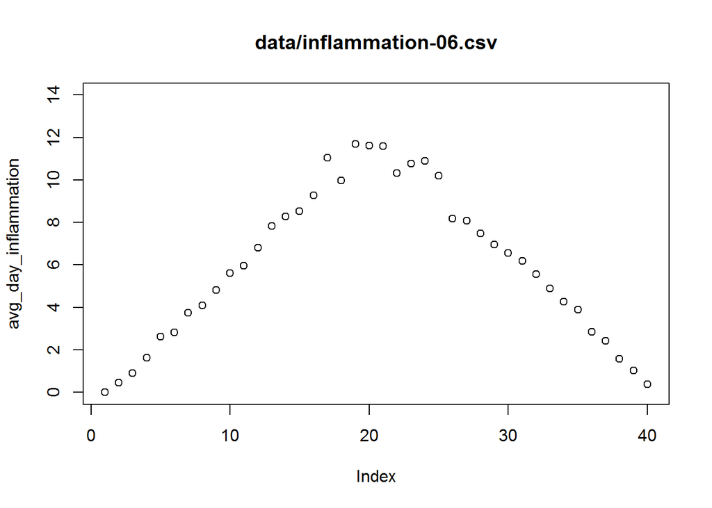

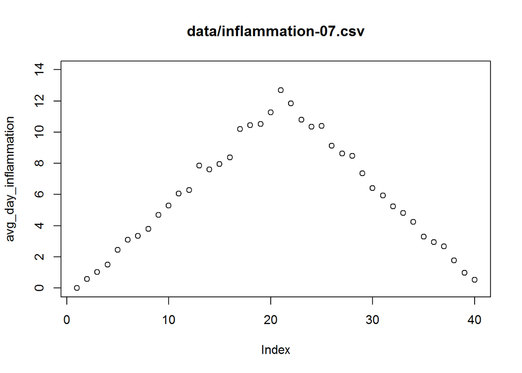

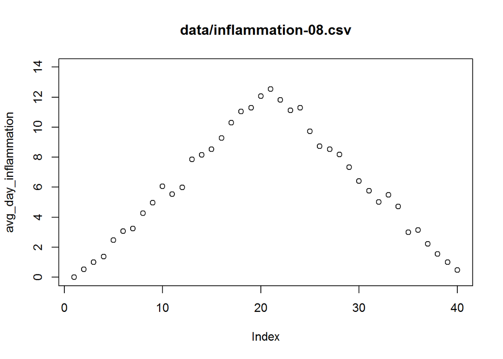

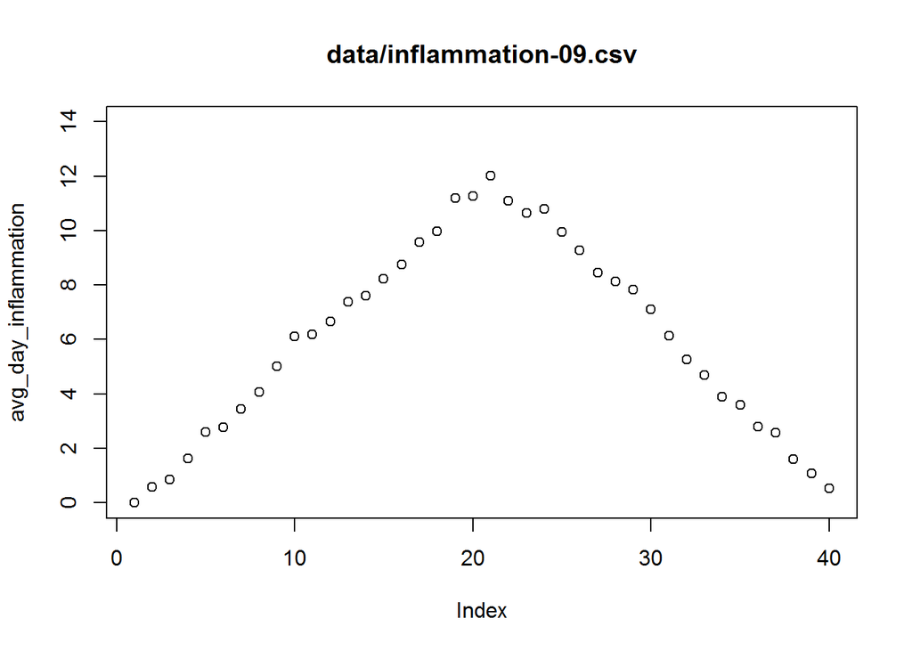

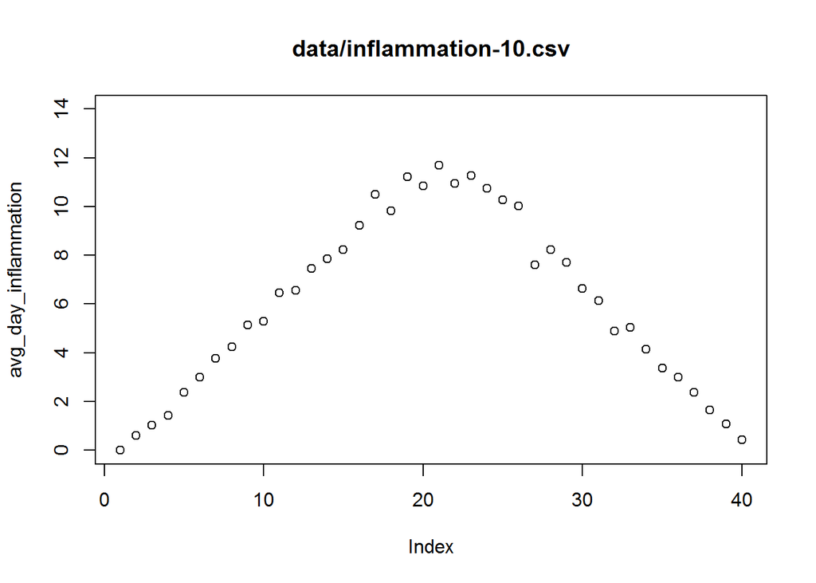

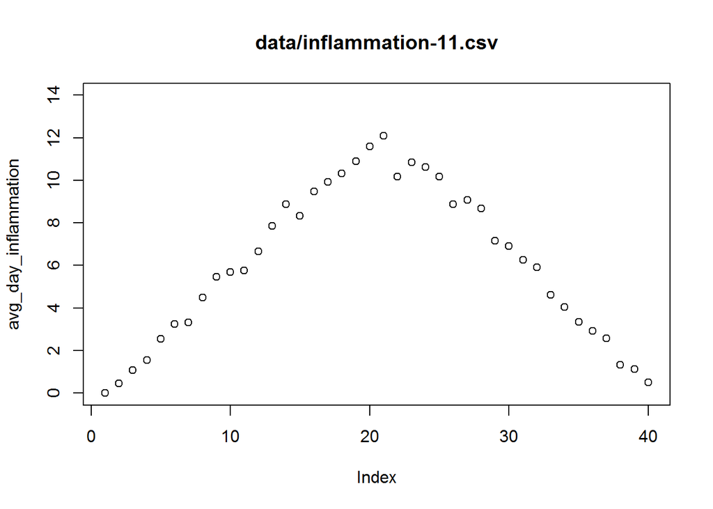

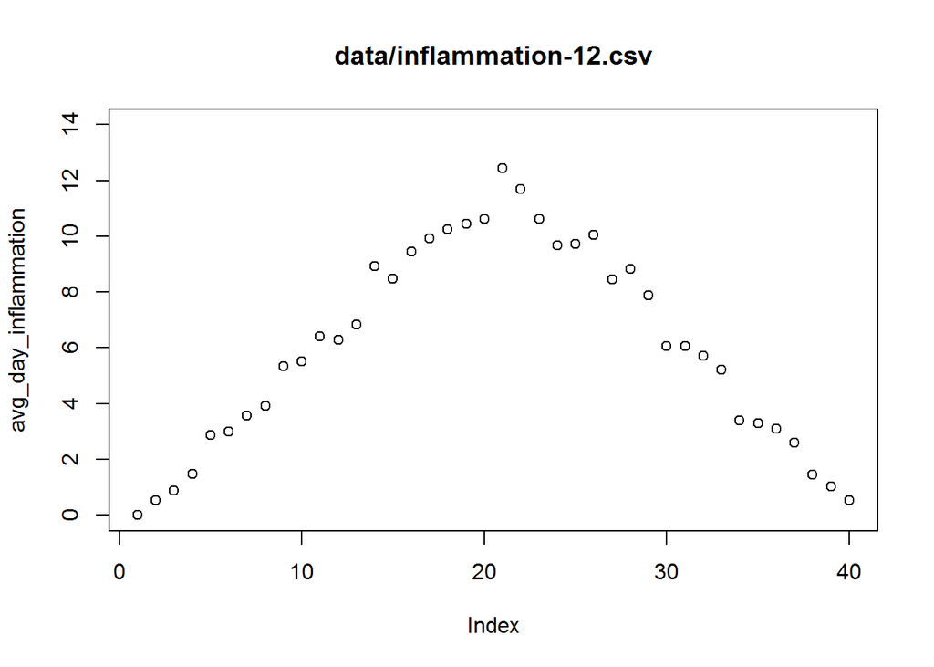

```r
# Loop over all files in directory "data" whose names contain "inflammation"
for ( datafile in list.files(path = "data", pattern = "inflammation", full.names = TRUE) )
{
  dat <- read.csv(file = datafile, header = FALSE)
  avg_day_inflammation <- apply(dat, 2, mean)
  plot(avg_day_inflammation, main = datafile, ylim=c(0,14))
}
```

In order to save and possibly share your results, it is handy to generate one or more pdf files with the plots. This can be easily done using the `pdf` function. Once the pdf file has been started with `pdf`, all graphical output will be inserted into the file. You will have to close the file using the function `dev.off`, where “dev” is an abbreviation of “device”:

```
pdf("inflammation.pdf")
# Insert plot commands here
dev.off()
```

**Note:** Don’t forget to use `dev.off`, otherwise the pdf file will be unreadable, and you won’t see any plots in RStudio. To check which output device you are currently using, use the function `dev.cur()`. It should say “pdf” if your pdf file is still open, and “null device” or “RStudioGD” if plots will be visualised normally.

To produce one pdf file with all plots in it, do the following:

```r
pdf("inflammation.pdf")
for ( datafile in list.files(path = "data", pattern = "inflammation", full.names = TRUE) )
{
  dat <- read.csv(file = datafile, header = FALSE)
  avg_day_inflammation <- apply(dat, 2, mean)
  plot(avg_day_inflammation, main = datafile, ylim=c(0,14))
}
dev.off()
```

# Lesson 3: Making Choices

It is useful if a program is able to automatically decide between different options, e.g., if a plot should be inserted into a file or not. In R, this is done using conditional statements that look like this:

```r
num <- 37
if ( num > 100 )
{
  print("greater")
} else
{
  print("not greater")
}
```

```
## [1] "not greater"
```

Some more decision-making, this time without `else`:

```r
num <- 53
if (num > 100) {
  print("num is greater than 100")
}
```

It is also possible to have more than two options:

```r
num <- 9
if (num > 0)
  {
    print("positive number")
  } else if (num == 0)
  {
    print("0")
  } else
  {
    print("negative number")
  }
```

```
## [1] "positive number"
```

Combined tests using `&` for “and” are possible, too:

```r
if (1 > 0 & -1 > 0) {
    print("both parts are true")
} else {
  print("at least one part is not true")
}
```

```
## [1] "at least one part is not true"
```

Using `|` for “or” also works:

```r
if (1 > 0 | -1 > 0) {
    print("at least one part is true")
} else {
  print("neither part is true")
}
```

```
## [1] "at least one part is true"
```

## Hands-on: Making choices

Write a program that analyses daily averages for each inflammation data file, plotting these averages if their maximum is below a threshold of `12`. To do this you’ll compute the averages using `avg_day_inflammation <- apply(dat, 2, mean)` as before, as well as `max(avg_day_inflammation)` to compute maximum values.

Solution:

```
pdf("inflammation.pdf")
threshold <- 12
for ( datafile in list.files(path = "data", pattern = "inflammation", full.names = TRUE) )
{
  dat <- read.csv(file = datafile, header = FALSE)
  avg_day_inflammation <- apply(dat, 2, mean)
  if (max(avg_day_inflammation) < threshold) {
    plot(avg_day_inflammation)
  }
}
dev.off()
```

# Lesson 4: Creating Functions

Functions are an essential ingredient for programming. Using functions, we can avoid having to repeat the same code over and over again, and we can bundle up parts of our program into logical blocks.

Without functions, the same program would have to be repeated for every input:

```r
s <- c("w", "i", "n", "d", "o", "w", "s", "8")
for( chr in s )
{
  if ( chr %in% seq(0, 9) )
  {
    print(c(chr, "is a digit"))
  } else if ( chr %in% c("a", "e", "i", "o", "u") )
  {
    print(c(chr, "is a vowel"))
  } else
  {
    print(c(chr, "is a consonant"))
  }
}
```

```
## [1] "w"              "is a consonant"
## [1] "i"          "is a vowel"
## [1] "n"              "is a consonant"
## [1] "d"              "is a consonant"
## [1] "o"          "is a vowel"
## [1] "w"              "is a consonant"
## [1] "s"              "is a consonant"
## [1] "8"          "is a digit"
```

```r
s <- c("w", "i", "n", "d", "o", "w", "s", "1", "0")
```

**Note:** R performed automatic variable type conversion between variable types “character” and “integer” for the statement `chr %in% seq(0, 9)`.

To avoid repetition, we can use a function that has one argument called `string`:

```r
classify_char <- function(string)
{
  print(string)
  for( chr in string )
  {
    if ( chr %in% seq(0, 9) )
    {
      print(c(chr, "is a digit"))
    } else if ( chr %in% c("a", "e", "i", "o", "u") )
    {
      print(c(chr, "is a vowel"))
    } else
    {
      print(c(chr, "is a consonant"))
    }
  }
}
# Let's try it:
s <- c("w", "i", "n", "d", "o", "w", "s", "1", "0")
classify_char(s)
```

```
## [1] "w" "i" "n" "d" "o" "w" "s" "1" "0"
## [1] "w"              "is a consonant"
## [1] "i"          "is a vowel"
## [1] "n"              "is a consonant"
## [1] "d"              "is a consonant"
## [1] "o"          "is a vowel"
## [1] "w"              "is a consonant"
## [1] "s"              "is a consonant"
## [1] "1"          "is a digit"
## [1] "0"          "is a digit"
```

**Important note:** A function must always be defined before you use it in your program for the first time!

Functions can also return a result, and they can define a default value that is used if the argument is not set:

```r
double_number <- function(nr = 0)
{
  return(2*nr)
}
double_number(2)
```

```
## [1] 4
```

```r
double_number(seq(1,3))
```

```
## [1] 2 4 6
```

```r
double_number()
```

```
## [1] 0
```